# Logistic Regression

### Data Wrangling

##### I have created a new dataset ‘alcohol-joined’ from two datasets of alcohol use habits and background info of Math and Portugese language course students, n=382 (198 females and 184 males, mean age of 16.6 years).

##### Data Files:

- The original datasets are student-mat.csv and student-por.csv
- The new dataset is alcohol-joined.csv

##### Script:

- The R script used to create the new dataset (*with comments explaining the process*) is create_alc.R

### Analysis

The new dataset ‘alc’ has 382 observations and 35 variables. The variables are:

```r
alc = read.table("data/alcohol-joined.csv", sep = ";", header = TRUE)
colnames(alc)
```

```
##  [1] "school"     "sex"        "age"        "address"    "famsize"
##  [6] "Pstatus"    "Medu"       "Fedu"       "Mjob"       "Fjob"
## [11] "reason"     "nursery"    "internet"   "guardian"   "traveltime"
## [16] "studytime"  "failures"   "schoolsup"  "famsup"     "paid"
## [21] "activities" "higher"     "romantic"   "famrel"     "freetime"
## [26] "goout"      "Dalc"       "Walc"       "health"     "absences"
## [31] "G1"         "G2"         "G3"         "alc_use"    "high_use"
```

##### The meaning of each variable is as follows:

- 1 school - student’s school (binary: ‘GP’ - Gabriel Pereira or ‘MS’ - Mousinho da Silveira)
- 2 sex - student’s sex (binary: ‘F’ - female or ‘M’ - male)
- 3 age - student’s age (numeric: from 15 to 22)
- 4 address - student’s home address type (binary: ‘U’ - urban or ‘R’ - rural)
- 5 famsize - family size (binary: ‘LE3’ - less or equal to 3 or ‘GT3’ - greater than 3)
- 6 Pstatus - parent’s cohabitation status (binary: ‘T’ - living together or ‘A’ - apart)
- 7 Medu - mother’s education (numeric: 0 - none, 1 - primary education (4th grade), 2 - 5th to 9th grade, 3 - secondary education or 4 - higher education)
- 8 Fedu - father’s education (numeric: 0 - none, 1 - primary education (4th grade), 2 - 5th to 9th grade, 3 - secondary education or 4 - higher education)
- 9 Mjob - mother’s job (nominal: ‘teacher’, ‘health’ care related, civil ‘services’ (e.g. administrative or police), ‘at_home’ or ‘other’)
- 10 Fjob - father’s job (nominal: ‘teacher’, ‘health’ care related, civil ‘services’ (e.g. administrative or police), ‘at_home’ or ‘other’)
- 11 reason - reason to choose this school (nominal: close to ‘home’, school ‘reputation’, ‘course’ preference or ‘other’)
- 12 guardian - student’s guardian (nominal: ‘mother’, ‘father’ or ‘other’)
- 13 traveltime - home to school travel time (numeric: 1 - <15 min., 2 - 15 to 30 min., 3 - 30 min. to 1 hour, or 4 - >1 hour)
- 14 studytime - weekly study time (numeric: 1 - <2 hours, 2 - 2 to 5 hours, 3 - 5 to 10 hours, or 4 - >10 hours)
- 15 failures - number of past class failures (numeric: n if 1<=n<3, else 4)
- 16 schoolsup - extra educational support (binary: yes or no)
- 17 famsup - family educational support (binary: yes or no)
- 18 paid - extra paid classes within the course subject (Math or Portuguese) (binary: yes or no)
- 19 activities - extra-curricular activities (binary: yes or no)
- 20 nursery - attended nursery school (binary: yes or no)
- 21 higher - wants to take higher education (binary: yes or no)
- 22 internet - Internet access at home (binary: yes or no)
- 23 romantic - with a romantic relationship (binary: yes or no)
- 24 famrel - quality of family relationships (numeric: from 1 - very bad to 5 - excellent)
- 25 freetime - free time after school (numeric: from 1 - very low to 5 - very high)
- 26 goout - going out with friends (numeric: from 1 - very low to 5 - very high)
- 27 Dalc - workday alcohol consumption (numeric: from 1 - very low to 5 - very high)
- 28 Walc - weekend alcohol consumption (numeric: from 1 - very low to 5 - very high)
- 29 health - current health status (numeric: from 1 - very bad to 5 - very good)
- 30 absences - number of school absences (numeric: from 0 to 93)

…and then there are the student’s grades that are averages of her Mathematics and Portugese language grades:

- 31 G1 - first period grade (numeric: from 0 to 20)
- 32 G2 - second period grade (numeric: from 0 to 20)
- 33 G3 - final grade (numeric: from 0 to 20, output target)

…the new variables, I have created in the data wrangling are:

- 34 alc_use - the average of workday and weekend alcohol consumption (numeric: from 1 - very low to 5 - very high)
- 35 high_use - if alc_use is more than 2, then TRUE else FALSE (binary: TRUE or FALSE)

### Relationship of alcohol consumption to other variables

Let’s look at a graphical summarization of the data:

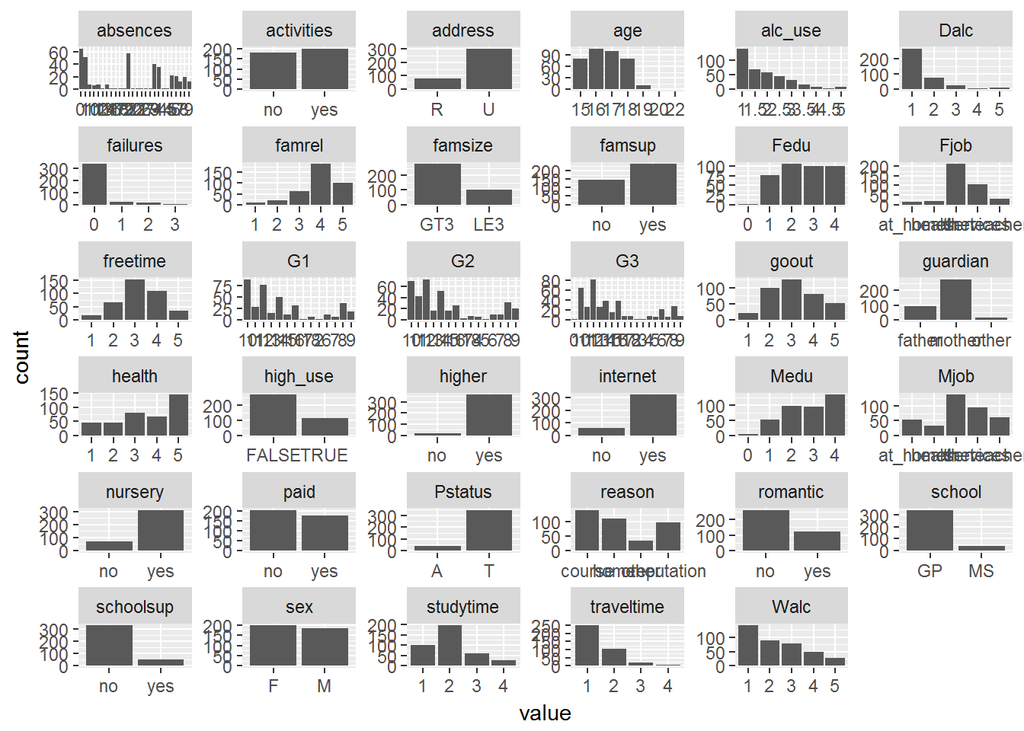

```r
# access the tidyverse libraries tidyr, dplyr, ggplot2
library(tidyverse);
# draw a bar plot of each variable
gather(alc) %>% ggplot(aes(value)) + facet_wrap("key", scales = "free") + geom_bar()
```

Interegsting variables to look at, considering their relation to alcohol consumption, would be, for example, sex, health, absences from classes and final grades. My hypothesis would be that men use more alcohol than women and that high alcohol consumption correlates with lower grades, more abscence and lower health status.

OK, let’s see how the aformentioned four variables correlate with alcohol consumption by cross tabulating them and drawing some plots to illustrate these correlations:

```r
# produce summary statistics by sex and mean alcohol use
alc %>% group_by(sex) %>% summarise(count = n(), mean_alcuse = mean(alc_use))
```

```
## # A tibble: 2 × 3
##      sex count mean_alcuse
##   <fctr> <int>       <dbl>
## 1      F   198    1.623737
## 2      M   184    2.173913
```

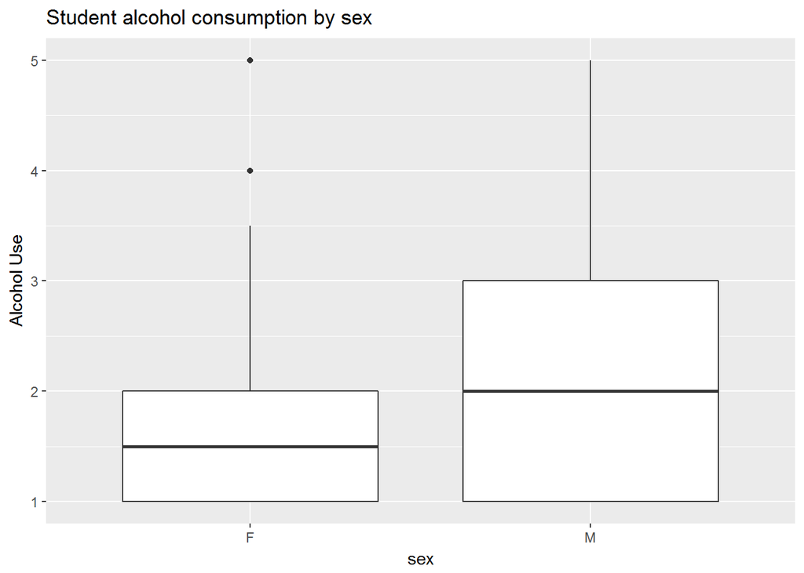

```r
# initialise a plot of sex and alc_use
g1 <- ggplot(alc, aes(x = sex, y = alc_use))

# define the plot as a boxplot and draw it
g1 + geom_boxplot() + ylab("Alcohol Use") + ggtitle("Student alcohol consumption by sex")
```

```r
# produce summary statistics by high_use and mean final grade
alc %>% group_by(high_use) %>% summarise(mean_grade = mean(G3))
```

```
## # A tibble: 2 × 2
##   high_use mean_grade
##      <lgl>      <dbl>
## 1    FALSE   11.73507
## 2     TRUE   10.80702
```

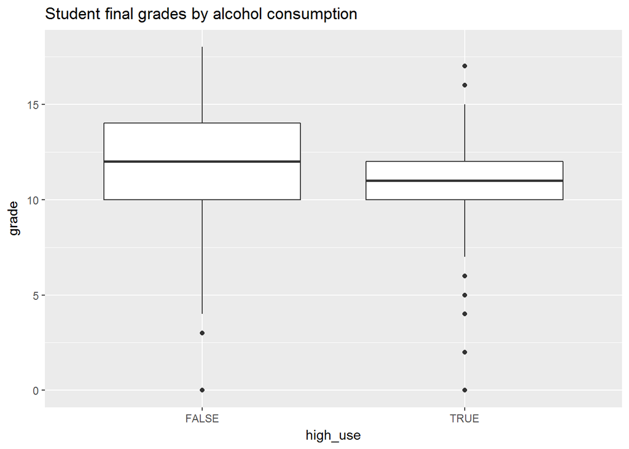

```r
# initialize a plot of high_use and G3
g2 <- ggplot(alc, aes(x = high_use, y = G3))

# define the plot as a boxplot and draw it
g2 + geom_boxplot() + ylab("grade") + ggtitle("Student final grades by alcohol consumption")
```

```r
# produce summary statistics by high_use and mean absences
alc %>% group_by(high_use) %>% summarise(mean_abs = mean(absences))
```

```
## # A tibble: 2 × 2
##   high_use mean_abs
##      <lgl>    <dbl>
## 1    FALSE 3.705224
## 2     TRUE 6.368421
```

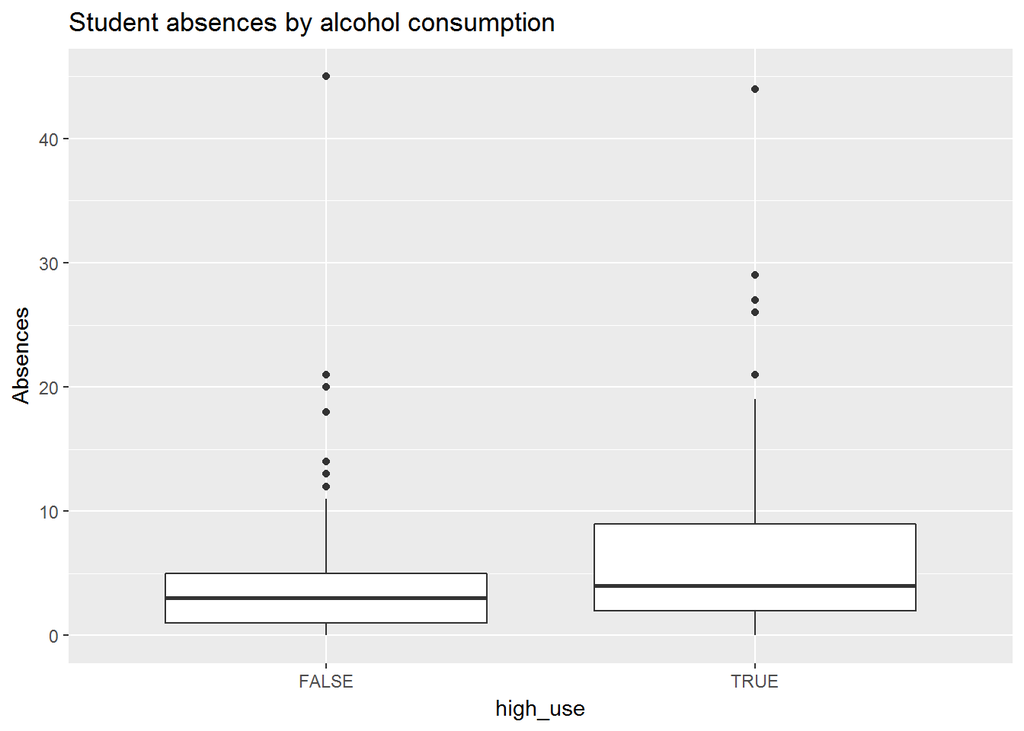

```r
# initialise a plot of high_use and absences
g3 <- ggplot(alc, aes(x = high_use, y = absences))

# define the plot as a boxplot and draw it
g3 + geom_boxplot() + ylab("Absences") + ggtitle("Student absences by alcohol consumption")
```

```r
# produce summary statistics by high_use and health
alc %>% group_by(high_use) %>% summarise(mean_health = mean(health))
```

```
## # A tibble: 2 × 2
##   high_use mean_health
##      <lgl>       <dbl>
## 1    FALSE    3.518657
## 2     TRUE    3.701754
```

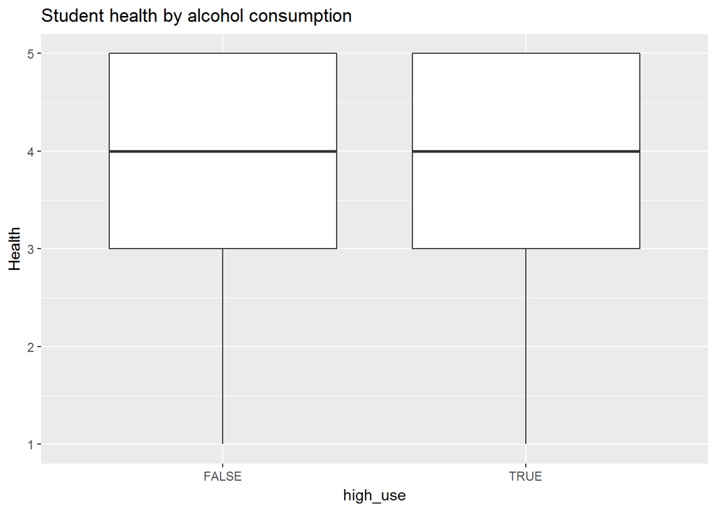

```r
# initialise a plot of high_use and health
g4 <- ggplot(alc, aes(x = high_use, y = health))

# define the plot as a boxplot and draw it
g4 + geom_boxplot() + ylab("Health") + ggtitle("Student health by alcohol consumption")
```

By looking at the cross-tabulaions and graphical presentations above, we can see that male students report bigger alcohol consumption than their female peers. High alcohol use also seems to correlate slightly with lower final grades and more absences from classes. On the other hand, alcohol use does not seem to correlate with health, but we have to keep in mind that the participants of this study are very young (15-22 year olds, mean age 16.6 years) and health problems created by alcohol mostly accumulate over time.

### Logistical regression analysis

Next we fit a logistic regression model to explain high consumption of alcohol.

```r
# find the model with glm()
m <- glm(high_use ~ G3 + absences + health + sex, data = alc, family = "binomial")
```

The summary of our fitted model is

```r
# print out a summary of the model
summary(m)
```

```
##
## Call:
## glm(formula = high_use ~ G3 + absences + health + sex, family = "binomial",
##     data = alc)
##
## Deviance Residuals:
##     Min       1Q   Median       3Q      Max
## -2.2762  -0.8492  -0.6146   1.0864   2.1396
##
## Coefficients:
##             Estimate Std. Error z value Pr(>|z|)
## (Intercept) -1.12067    0.57069  -1.964   0.0496 *
## G3          -0.07427    0.03584  -2.072   0.0382 *
## absences     0.09277    0.02303   4.028 5.62e-05 ***
## health       0.04026    0.08742   0.460   0.6452
## sexM         0.96946    0.24325   3.985 6.74e-05 ***
## ---
## Signif. codes:  0 '***' 0.001 '**' 0.01 '*' 0.05 '.' 0.1 ' ' 1
##
## (Dispersion parameter for binomial family taken to be 1)
##
##     Null deviance: 465.68  on 381  degrees of freedom
## Residual deviance: 425.30  on 377  degrees of freedom
## AIC: 435.3
##
## Number of Fisher Scoring iterations: 4
```

… and the coefficients of the model as odds ratios with confidence intervals is

```r
# compute odds ratios (OR)
OR <- coef(m) %>% exp

# compute confidence intervals (CI)
CI = exp(confint(m))

# print out the odds ratios with their confidence intervals
cbind(OR, CI)
```

```
##                    OR     2.5 %    97.5 %
## (Intercept) 0.3260597 0.1046920 0.9862794
## G3          0.9284223 0.8648509 0.9957691
## absences    1.0972091 1.0509220 1.1503430
## health      1.0410775 0.8780964 1.2380464
## sexM        2.6365084 1.6462472 4.2800640
```

When we look at the above printout, we can see that final grades, amount of absences and gender can be used to predict the likelihood of high alcohol consumption reasonably well: lower grades, more absences, and being male increase the possibility of high alcohol use. On the other hand, health status doesn’t seem to correlate with high alcohol use, which might be due to young age of participants.

### Predictive Power of the Model

Using the variables which, according to our logistic regression model, have a statistical relationship with alcohol consumption, let’s perform a 2x2 cross tabulation of predictions versus the actual values and visualize both the actual values and predictions graphically.

```r
# predict the probability of high alcohol use
probabilities <- predict(m, type = "response")

# add the predicted probabilities to 'alc'
alc <- mutate(alc, probability = probabilities)

# use probabilities to predict high alcohol use
alc <- mutate(alc, prediction = probability > 0.5)

# tabulate target variable vs predictions
table(high_use = alc$high_use, prediction = alc$prediction)
```

```
##         prediction
## high_use FALSE TRUE
##    FALSE   256   12
##    TRUE     87   27
```

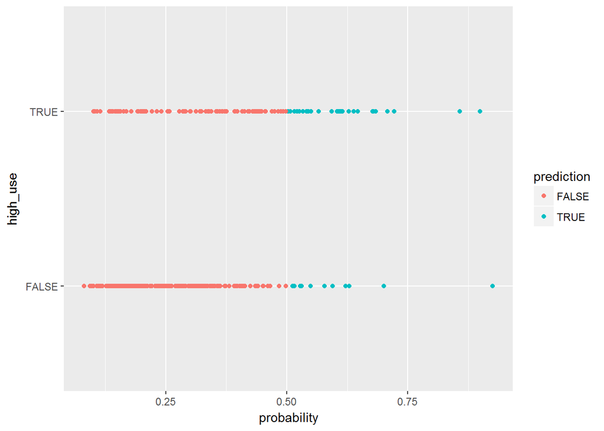

```r
# initialize a plot of high_use vs. probability
g <- ggplot(alc, aes(x = probability, y = high_use, col=prediction))

# define the geom as points and draw the plot
g + geom_point()
```

Our model estimates that 87 participants would not be and 12 would be high users when actually the opposite was true. The model accurately identified 27 participants as high users and 256 as not. Our graph tries to visualize the same, although the amount of accurately predicted non-high users (n=256) and inaccurately predicted high users (n=87) look quite similar (see red/left side of graph).

Let’s now compute the total proportion of inaccurately classified observations (i.e. incorrect predicitions, training error):

```r
# define a loss function (mean prediction error)
loss_func <- function(class, prob) {
  n_wrong <- abs(class - prob) > 0.5
  mean(n_wrong)
}

# call loss_func to compute the average number of wrong predictions in the (training) data
loss_func(class = alc$high_use, prob = alc$probability)
```

```
## [1] 0.2591623
```

… and, as a BONUS, do a 10-fold cross-validation for our model:

```r
# K-fold cross-validation
library(boot)
cv <- cv.glm(data = alc, cost = loss_func, glmfit = m, K = 10)

# average number of wrong predictions in the cross validation
cv$delta[1]
```

```
## [1] 0.2670157
```

The training error of our model (0.26) is lower than if we were just to guess whether a person has high or low alcohol use.

The validation error in our 10-fold cross-validation is about the same as in the model introduced in DataCamp (high_use ~ failures + absences + sex), which suggests that our model does equally well as the DataCamp model.

On the other hand, if we were to change our independent variable G3 (grade) to goout (how much the person goes out with his/her friends), the predictive power of our model increases, as can be seen in this second cross-validation:

```r
# find the model with glm
m2 <- glm(high_use ~ goout + absences + health + sex, data = alc, family = "binomial")

# K-fold cross-validation
cv <- cv.glm(data = alc, cost = loss_func, glmfit = m2, K = 10)

# average number of wrong predictions in the cross validation
cv$delta[1]
```

```
## [1] 0.2146597
```